# case_study_RT_accuracy

Yanting Li

2023-06-16

## Experiment design

Describe the design of the experiment in your own words.

The experiment consists of four phases: Practice, Exposure, Test, and Baseline. Among them, the Exposure Phase has 3 blocks whereas the other three phrases all have 1 block, so there are 6 blocks in total. Each block contains 6 trials. In each trial, participants will be asked to judge whether the word displayed on the computer screen (e.g., “bard”) matches the final word of the sentence they hear (e.g., “Please reserve me a spot.”).

Participants are randomly split into two groups (Accent vs. Contro) and go through the four phases. The only difference between the two groups is the auditory material used for the Exposure Phrase.

In the Practice Phase, participants are familiarized with the task by listening to sentences produced by Native American English (AE) Talker 1. In the Exposure Phase, participants listens to either a) Mandarin accented Talker 1 (for Accent group), or b) Native AE Talker (for Control group) 2. In the Test Phase, all participants listen to Mandarin accented Talker 1. Finally, in the Baseline Phase, all participants listens to Native AE Talker 1 again. The purpose of this phase is to capture changes in performance due to task practice effect so inter-participant variability can be corrected.

## Data cleaning

### 1. Examine RT distribution

Examine the distribution of RT (subjMean_BlockRT) across subjects. Does it make sense?

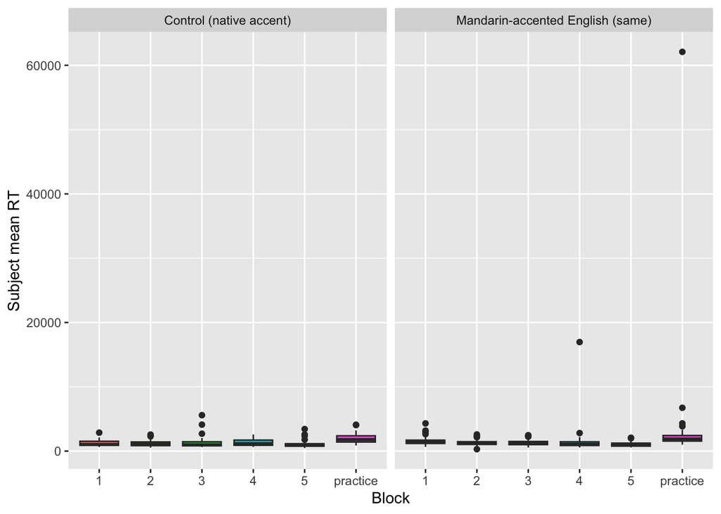

Distribution of subjects mean RTs by Block and Condition, prior to outlier exclusions.

It seems that there is a very obvious outlier for the practice block and another potential outlier in the 4th block, both for the Accent group.

## 2. Data exclusion

Describe the procedure you take to exclude outliers (subjects, trials, etc.).

### Exclusion by subject

Describe your exclusion criteria based on a subject’s performance.

e.g., We want to identify and remove subjects who consistently registered slow response times because they did not perform the task faithfully (e.g., multi-tasking) or because their computer equipment did not provide reliable recording of RTs over the web.

We want to identify and remove subjects who consistently registered slow response times because they did not perform the task faithfully (e.g., multi-tasking) or because their computer equipment did not provide reliable recording of RTs over the web. In order to do that, we will look within conditions and exclude participants with overall mean RT (across all blocks) that is 3 standard deviation longer than the overall mean RT across all participants.

```
## [1] 7
```

```
## [1] 2
```

```
## [1] 5
```

Re-examine RT distribution after subject exclusion.

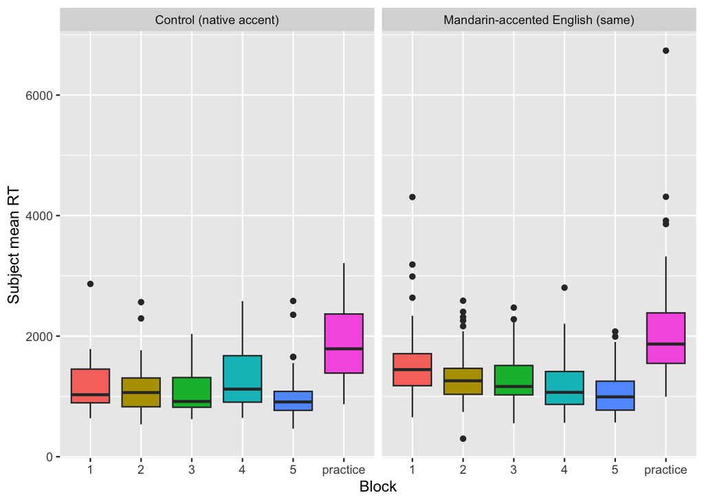

### Exclusion by trial with extreme RTs

The second step of outlier removal was to exclude trials with atypical RTs. Describe your exclusion criteria by trial and do a second round of exclusion.

We want to identify and remove trials with exceptionally slow response times compared to the other trials in the same block because such trials might not be a result of a sudden interruption that is not related to the task. For each participant left in our dataset, we will look within each block and exclude trials with RT that is 3 standard deviation longer than the mean.

```
## [1] 0
```

Q: Did trial-wise outlier exclusion disproportionately affect any experimental Conditions?

Since nothing got excluded according to the step above, this procedure did not affect any experimental Conditions.

Q: Examine the mean RTs by block. Do they vary a lot before and after trial exclusion? Describe the effects.

Since nothing got excluded according to the step above, this procedure did not have any effects on the mean RTs. (I am kind of confused by this result though - is this normal? I reconsidered my criteria, but still believe that each participants should be comparing with themselves, and within the same block only. I also think that we shouldn’t go back and change our exclusion criteria just because it doesn’t end up excluding anything, so I did not make a change here. However, this should be based on the fact that the original criteria makes sense, but I am not entirely sure if mine makes sense in the first place.)

Now that we’ve excluded extreme subject and trial outliers, we can look at the practice and baseline data to assess our high-level predictions about how participants should perform on this web-based task.

1. **One data pattern that we expect to find is that performance (both RTs and accuracy) in the practice and baseline blocks is comparable across experimental conditions.** We expect this because these blocks of the experiment were identical across conditions (i.e., native-accented stimuli presented in the clear).
   - … *if performance in the **practice block** differs substantially across conditions*, we would need to consider whether the subjects in each condition were sampled from the same underlying population (e.g., did we run all conditions at approximately the sme time of day?).
   - … *if performance in the **baseline block** differs substantially across conditions*, we would need to consider whether exposure to different types of speech during the main block of the experiment induced overall differences in task performance (in which case the baseline block doesn’t provide a reliable condition-independent “baseline” for normalization purposes).
2. **A second data pattern that we expect to find is evidence of improvement (adaptation) over the course of the task.** One way this would manifest is faster RTs and increased accuracy in the post-experiment baseline block, relative to the practice phase.

## Summary of exclusion criteria:

- Participant-level exclusions:
  - We looked at the overall mean RT across all blocks of each participant. If a participant, compared to others within the same Condition, has an overall mean RT that is obviously much higher (3 standard deviation from the mean), then we will exclude all data of this participant.
- Trial-level exclusions:
  - For each participant, we will look within each block. If a trial, compared to other trials done by the same participant within the same block, has an RT that is obviously much higher (3 standard deviation from the mean), then we will exclude that trial from the block.

(This is a question that arose from doing this case study: is there a convention about the order of conducting participant- vs. trial-level exclusions? I am curious because if a normal participant has one very extreme long trial for each trial, then it’s possible that his/her overall mean RT will become an outlier, but if we exclude those trials first, his/her overall mean RT might be normal, right?)

We applied the same exclusion criteria across all RT and error analyses.

## Normalize experimental RTs relative to baseline

Now that we’ve completed all trial-wise RT exclusions, we can calculate *normalized* RTs that take into account each subject’s baseline speed on this task. For this procedure, we adjust the RTs on each trial by subtracting out the corresponding subject’s mean RT during the baseline phase. We refer to the resulting measure as *adjusted RTs*.

```r
# calculate each subject's mean Baseline RT
# and subtract that value from experimental RTs

dat_out2 <- d.all2[!(d.all2$WorkerId %in% trialOutliers$WorkerId), ]

dat_out2 %<>%
  group_by(WorkerId) %>%
  mutate(
    # calculate subject-wise mean RTs during baseline block
    meanBaselineRT = mean(RT[PartOfExp == "baseline"]),

    # calculate normalized RTs
    AdjustedRT = RT - meanBaselineRT,

    # calculate subject-wise mean Adjusted RT across Blocks 1-4
    meanAdjustedRT = mean(AdjustedRT[PartOfExp == "main"])
  )
```

Now we want to check the distribution of adjuted RTs to make sure it seems reasonable, given our expectations about task performance.

Note that we expect baseline RTs to be faster on average than RTs during the experimental block, regardless of exposure condition. We expect this for two reasons. First, the baseline task occurred at the end of the experiment, after participants had adapted to the task. Second, *all* participants heard native accented speech during the baseline phase; hence, there was no need for accent adaptation during this phase.

```r
# ratio of negative meanAdjusted RTs among all meanAdjusted RTs
nrow(filter(dat_out2, meanAdjustedRT<0))/nrow(dat_out2)
```

```
## [1] 0.1157895
```

# Modeling strategy

## Model building and assessment

RTs were analyzed using linear mixed effects regression, as implemented in the lme4 package (version 1.1-10: Bates, Maechler, Bolker, \& Walker, 2014) in R (R Core Team, 2014). Response accuracy (incorrect vs. correct response) was analyzed using mixed effects logistic regression (see Jaeger, 2008). All mixed effects models were specified with the maximal random effects structure justified by the experimental design: that is, by-subject and by-item random intercepts, by-subject random slopes for all design variables manipulated within subjects, and by-item random slopes for all design variables manipulated within items. If the definitionally maximal model failed to converge within ten thousand iterations, the model was systematically simplified in a step-wise fashion until the model converged. These steps involved removing correlations among random effects; dropping the random effects term with the least variance; and removing fixed effects that were inconsequential for the theory being tested (i.e., counterbalancing nuisance variables).

## Variable coding

Unless otherwise specified, all numeric predictors were centered and categorical predictors were coded as sum contrasts, in order to reduce collinearity among predictors.

# Experiment 1: Adaptation to Mandarin-accented English

## Participants

Examine the number of participants per condition.

```r
# number of participants in the Accent group:
nrow(exp1 %>%
  select(WorkerId, Condition) %>%
  unique() %>%
  filter(Condition == "Mandarin-accented English (same)"))
```

```
## [1] 50
```

```r
# number of participants in the Control group:
nrow(exp1 %>%
  select(WorkerId, Condition) %>%
  unique() %>%
  filter(Condition == "Control (native accent)"))
```

```
## [1] 45
```

## Exp1 Response Times

Visualize the changes of RTs across blocks by condition.

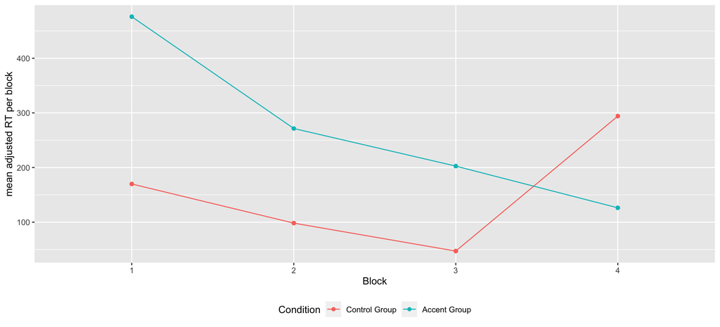

Average RTs by exposure condition in Experiment 1.

We assess the effect of exposure condition (Mandarin-accented English vs. control) on processing speed separately for RTs during the exposure phase and the test phase. To assess the *change* in RTs during the course of exposure, we split the 18-trial exposure phase into three blocks of 6 trials and use the resulting Block variable as a categorical predictor of RTs. We use linear mixed-effects models to simultaneously model subject and item random effects.

#### Exposure

A linear mixed effects model was fit to adjusted RTs for correct responses during the exposure phase.

Describe your fixed effects and random effects. Describe how each variable is coded.

```r
# Model specification:
  # dependent variable: AdjustedRT
  # independent variable: Block (the variable of interest)
  #                       Condition (another variable of interest)
  #                       WorkerID (random effect - subject)
  #                       Word (random effect - item)

# by-block analysis of RTs during EXPOSURE
expo <- exp1 %>%
  filter(Phase == "Exposure phase", CorrectResponse == "correct", Block == 1 | 2 | 3) %>%
  select(WorkerId, Condition, Block, AdjustedRT, Word)
expo$WorkerId <- as.factor(expo$WorkerId)
expo$Word <- as.factor(expo$Word)

modelexpo <- lmer(AdjustedRT ~ Block*Condition + (1 + Block|WorkerId) + (1 + Block + Condition|Word), data = expo)
summary(modelexpo)
```

```
## Linear mixed model fit by REML. t-tests use Satterthwaite's method [
## lmerModLmerTest]
## Formula: AdjustedRT ~ Block * Condition + (1 + Block | WorkerId) + (1 +
##     Block + Condition | Word)
##    Data: expo
##
## REML criterion at convergence: 23763.7
##
## Scaled residuals:
##     Min      1Q  Median      3Q     Max
## -1.9965 -0.4615 -0.1441  0.2145  9.8800
##
## Random effects:
##  Groups   Name              Variance Std.Dev. Corr
##  WorkerId (Intercept)       105499   324.81
##           Block2             38243   195.56   -0.21
##           Block3             43996   209.75   -0.33  0.73
##  Word     (Intercept)        45365   212.99
##           Block2             23718   154.01   -0.49
##           Block3             15577   124.81   -0.77  0.70
##           ConditionAccented   7227    85.01   -0.22 -0.63  0.11
##  Residual                   286049   534.84
## Number of obs: 1527, groups:  WorkerId, 95; Word, 24
##
## Fixed effects:
##                          Estimate Std. Error      df t value Pr(>|t|)
## (Intercept)                287.02      60.01   45.15   4.783 1.88e-05 ***
## Block2                    -112.60      50.45   27.28  -2.232 0.034043 *
## Block3                    -189.77      47.74   29.72  -3.975 0.000414 ***
## ConditionAccented         -121.84      44.80   90.23  -2.720 0.007835 **
## Block2:ConditionAccented    41.34      39.37   95.39   1.050 0.296308
## Block3:ConditionAccented    73.89      40.30   85.98   1.833 0.070211 .
## ---
## Signif. codes:  0 '***' 0.001 '**' 0.01 '*' 0.05 '.' 0.1 ' ' 1
##
## Correlation of Fixed Effects:
##             (Intr) Block2 Block3 CndtnA Bl2:CA
## Block2      -0.464
## Block3      -0.587  0.610
## CndtnAccntd -0.051 -0.144  0.030
## Blck2:CndtA  0.007 -0.004 -0.005 -0.412
## Blck3:CndtA  0.005 -0.004 -0.007 -0.458  0.570
## optimizer (nloptwrap) convergence code: 0 (OK)
## boundary (singular) fit: see help('isSingular')
```

```r
contrasts(expo$Condition)
```

```
##                                  Accented
## Control (native accent)                 1
## Mandarin-accented English (same)       -1
```

The result indicates that first of all, Block has a significant effect on the AdjustedRT during the exposure phase. Block 1, while holding everything else constant, has the longest estimated AdjustedRT, while Block 2 has a significantly lower, and Block 3 has a yet lower estimated AdjustedRT. This means that with the progress of the experiments, participants are in general responding more and more quickly.

Condition wise, since the Accented group is coded as -1, the negative beta indicates that the Accented group has a significantly longer RT compared to the Control group, when everything else is held constant. This means that in general, it is taking the Accented group longer time to respond, compared to the Controlled group. The interaction between Block and Condition is not significant though.

#### Test

```r
# Model specification:
  # dependent variable: AdjustedRT
  # independent variable: Condition (the variable of interest)
  #                       Word (random effect - item)

# by-block analysis of RTs during TEST
test <- exp1 %>%
  filter(Phase == "Test phase", CorrectResponse == "correct") %>%
  select(WorkerId, Condition, AdjustedRT, Word)
expo$WorkerId <- as.factor(expo$WorkerId)
expo$Word <- as.factor(expo$Word)

modeltest <- lmer(AdjustedRT ~ Condition + (1 + Condition|Word), data = test)
summary(modeltest)
```

```
## Linear mixed model fit by REML. t-tests use Satterthwaite's method [
## lmerModLmerTest]
## Formula: AdjustedRT ~ Condition + (1 + Condition | Word)
##    Data: test
##
## REML criterion at convergence: 7825.2
##
## Scaled residuals:
##     Min      1Q  Median      3Q     Max
## -2.4664 -0.4197 -0.1370  0.2131  9.0561
##
## Random effects:
##  Groups   Name              Variance Std.Dev. Corr
##  Word     (Intercept)        30694   175.20
##           ConditionAccented   2946    54.28   1.00
##  Residual                   414092   643.50
## Number of obs: 496, groups:  Word, 24
##
## Fixed effects:
##                   Estimate Std. Error     df t value Pr(>|t|)
## (Intercept)         195.23      46.48  21.57   4.201 0.000383 ***
## ConditionAccented    95.28      31.24  54.19   3.050 0.003540 **
## ---
## Signif. codes:  0 '***' 0.001 '**' 0.01 '*' 0.05 '.' 0.1 ' ' 1
##
## Correlation of Fixed Effects:
##             (Intr)
## CndtnAccntd 0.338
## optimizer (nloptwrap) convergence code: 0 (OK)
## boundary (singular) fit: see help('isSingular')
```

```r
contrasts(expo$Condition)
```

```
##                                  Accented
## Control (native accent)                 1
## Mandarin-accented English (same)       -1
```